# EPL Dataset Analysis using R

Sanjeev N S

2023-12-13

*Introduction there are many teams in england premier league.EPL is the top ranking football league where famous teams like manchester city,liverpool,chelsea etc plays.recent times,there is debate for machester is blue or red.In this analysis we find manchester is blue or red

```r
#install.packages("ggplot2")
library(ggplot2)
#install.packages("gridExtra")  # Install gridExtra for grid.arrange function
library(gridExtra)
#install.packages("dplyr")
library(dplyr)
dataset <- read.csv("C:\\Users\\sanjeev\\Desktop\\7TH SEM\\FDA\\archive\\Premier_League.csv")
```

```r
# View the structure of the dataset (column names, data types)
str(dataset)
```

```
## 'data.frame':    380 obs. of  39 variables:
##  $ date            : chr  "28th May 2023" "28th May 2023" "28th May 2023" "28th May 2023" ...
##  $ clock           : chr  "4:30pm" "4:30pm" "4:30pm" "4:30pm" ...
##  $ stadium         : chr  "Emirates Stadium" "Villa Park" "Gtech Community Stadium" "Stamford Bridge" ...
##  $ attendance      : num  60095 42212 17120 40130 25198 ...
##  $ Home.Team       : chr  "Arsenal" "Aston Villa" "Brentford" "Chelsea" ...
##  $ Goals.Home      : int  5 2 1 1 1 1 1 2 2 4 ...
##  $ Away.Team       : chr  "Wolverhampton Wanderers" "Brighton and Hove Albion" "Manchester City" "Newcastle United" ...
##  $ Away.Goals      : int  0 1 0 1 1 0 4 1 1 4 ...
##  $ home_possessions: num  51 40.3 34.4 64.4 66 37.8 52.1 48.2 53.2 30.9 ...
##  $ away_possessions: num  49 59.7 65.6 35.6 34 62.2 47.9 51.8 46.8 69.1 ...
##  $ home_shots      : int  14 12 11 22 15 13 19 13 21 15 ...
##  $ away_shots      : int  6 8 17 13 7 7 11 16 10 30 ...
##  $ home_on         : int  8 5 4 5 3 6 2 4 8 10 ...
##  $ away_on         : int  0 4 3 4 4 2 7 3 3 8 ...
```

[output cut: 25 more lines]

**BASIC ANALYSIS**

```r
# Summary statistics of numerical columns
summary(dataset)
```

```
##      date              clock             stadium            attendance
##  Length:380         Length:380         Length:380         Min.   : 9972
##  Class :character   Class :character   Class :character   1st Qu.:29494
##  Mode  :character   Mode  :character   Mode  :character   Median :38000
##                                                           Mean   :40170
##                                                           3rd Qu.:53283
##                                                           Max.   :75546
##   Home.Team           Goals.Home     Away.Team           Away.Goals
##  Length:380         Min.   :0.000   Length:380         Min.   :0.000
##  Class :character   1st Qu.:1.000   Class :character   1st Qu.:0.000
##  Mode  :character   Median :1.000   Mode  :character   Median :1.000
##                     Mean   :1.634                      Mean   :1.218
##                     3rd Qu.:2.000                      3rd Qu.:2.000
##                     Max.   :9.000                      Max.   :6.000
##  home_possessions away_possessions   home_shots      away_shots
##  Min.   :18.30    Min.   :18.90    Min.   : 1.00   Min.   : 1.00
##  1st Qu.:39.90    1st Qu.:40.40    1st Qu.:10.00   1st Qu.: 8.00
##  Median :51.00    Median :49.00    Median :14.00   Median :11.00
##  Mean   :50.45    Mean   :49.55    Mean   :13.97   Mean   :11.31
##  3rd Qu.:59.60    3rd Qu.:60.10    3rd Qu.:17.00   3rd Qu.:15.00
##  Max.   :81.10    Max.   :81.70    Max.   :33.00   Max.   :30.00
##     home_on          away_on          home_off         away_off
##  Min.   : 0.000   Min.   : 0.000   Min.   : 0.000   Min.   : 0.000
##  1st Qu.: 3.000   1st Qu.: 2.000   1st Qu.: 3.000   1st Qu.: 3.000
##  Median : 5.000   Median : 4.000   Median : 5.000   Median : 4.000
##  Mean   : 4.913   Mean   : 3.897   Mean   : 5.111   Mean   : 4.237
##  3rd Qu.: 7.000   3rd Qu.: 5.000   3rd Qu.: 7.000   3rd Qu.: 6.000
##  Max.   :15.000   Max.   :11.000   Max.   :15.000   Max.   :12.000
##   home_blocked    away_blocked      home_pass       away_pass
##  Min.   : 0.00   Min.   : 0.000   Min.   :49.70   Min.   :52.70
##  1st Qu.: 2.00   1st Qu.: 1.000   1st Qu.:75.28   1st Qu.:75.28
##  Median : 3.00   Median : 3.000   Median :81.30   Median :80.50
##  Mean   : 3.95   Mean   : 3.179   Mean   :79.82   Mean   :79.23
##  3rd Qu.: 5.00   3rd Qu.: 4.000   3rd Qu.:85.20   3rd Qu.:84.50
##  Max.   :14.00   Max.   :12.000   Max.   :93.20   Max.   :92.90
##   home_chances    away_chances    home_corners     away_corners
##  Min.   :0.000   Min.   :0.000   Min.   : 0.000   Min.   : 0.000
##  1st Qu.:1.000   1st Qu.:0.000   1st Qu.: 3.000   1st Qu.: 2.000
##  Median :2.000   Median :1.000   Median : 5.000   Median : 4.000
##  Mean   :1.697   Mean   :1.395   Mean   : 5.637   Mean   : 4.471
```

[output cut: 15 more lines]

```
##  Max.   :90.00   Max.   :90.00   Max.   :9.00   Max.   :11.000
##    home_fouls      away_fouls     home_yellow     away_yellow
##  Min.   : 3.00   Min.   : 3.00   Min.   :0.000   Min.   :0.000
##  1st Qu.: 8.00   1st Qu.: 8.75   1st Qu.:1.000   1st Qu.:1.000
##  Median :10.00   Median :11.00   Median :2.000   Median :2.000
##  Mean   :10.61   Mean   :10.96   Mean   :1.676   Mean   :1.939
##  3rd Qu.:13.00   3rd Qu.:13.00   3rd Qu.:3.000   3rd Qu.:3.000
##  Max.   :23.00   Max.   :25.00   Max.   :6.000   Max.   :7.000
##     home_red          away_red          links
##  Min.   :0.00000   Min.   :0.00000   Length:380
##  1st Qu.:0.00000   1st Qu.:0.00000   Class :character
##  Median :0.00000   Median :0.00000   Mode  :character
##  Mean   :0.05263   Mean   :0.02632
##  3rd Qu.:0.00000   3rd Qu.:0.00000
##  Max.   :2.00000   Max.   :1.00000
```

```r
# Check the first few rows of the dataset
head(dataset,10)
```

```
##             date  clock                 stadium attendance         Home.Team
## 1  28th May 2023 4:30pm        Emirates Stadium      60095           Arsenal
## 2  28th May 2023 4:30pm              Villa Park      42212       Aston Villa
## 3  28th May 2023 4:30pm Gtech Community Stadium      17120         Brentford
## 4  28th May 2023 4:30pm         Stamford Bridge      40130           Chelsea
## 5  28th May 2023 4:30pm           Selhurst Park      25198    Crystal Palace
## 6  28th May 2023 4:30pm           Goodison Park      39201           Everton
## 7  28th May 2023 4:30pm             Elland Road      36871      Leeds United
## 8  28th May 2023 4:30pm  The King Power Stadium      32183    Leicester City
## 9  28th May 2023 4:30pm            Old Trafford      73465 Manchester United
## 10 28th May 2023 4:30pm      St. Mary's Stadium      31129       Southampton
##    Goals.Home                Away.Team Away.Goals home_possessions
## 1           5  Wolverhampton Wanderers          0             51.0
## 2           2 Brighton and Hove Albion          1             40.3
## 3           1          Manchester City          0             34.4
```

[output cut: 73 more lines]

```r
# Check the last few rows of the dataset
tail(dataset,10)
```

```
##                date  clock                   stadium attendance
## 371 7th August 2022 2:00pm    The King Power Stadium      31794
## 372 7th August 2022 2:00pm              Old Trafford      73711
## 373 7th August 2022 4:30pm            London Stadium      62443
## 374 6th August 2022 12:30p            Craven Cottage      25000
## 375 6th August 2022 3:00pm          Vitality Stadium      10000
## 376 6th August 2022 3:00pm               Elland Road      36347
## 377 6th August 2022 3:00pm St James' Park, Newcastle      52245
## 378 6th August 2022 3:00pm Tottenham Hotspur Stadium      61732
## 379 6th August 2022 5:30pm             Goodison Park      39254
## 380 5th August 2022 8:00pm             Selhurst Park      25286
##             Home.Team Goals.Home                Away.Team Away.Goals
## 371    Leicester City          2                Brentford          2
## 372 Manchester United          1 Brighton and Hove Albion          2
## 373   West Ham United          0          Manchester City          2
```

[output cut: 73 more lines]

**find stadium which has highest attendence**

```r
# Find the row with the highest attendance
max_attendance_row <- dataset[which.max(dataset$attendance), ]
```

```r
# Extract the relevant information
highest_attendance <- max_attendance_row$attendance
stadium_with_highest_attendance <- max_attendance_row$stadium
home_team_playing <- max_attendance_row$`Home.Team`
away_team_playing <- max_attendance_row$`Away.Team`
```

```r
# Print the results
cat("Stadium with highest attendance:", stadium_with_highest_attendance, "\n")
```

```
## Stadium with highest attendance: Old Trafford
```

```r
cat("Teams playing in the match:", home_team_playing, "vs", away_team_playing, "\n")
```

```
## Teams playing in the match: Manchester United vs Manchester City
```

```r
cat("Attendance:", highest_attendance, "spectators", "\n")
```

```
## Attendance: 75546 spectators
```

*The above result shows the stadium which has highest attendence , teams playing and attendence . so we can analyse that man city and man united are great rivals and many intrested to watch the match

**Calculate total yellow and red cards for each team home an away**

```r
# Calculate total yellow and red cards for each team at home
home_yellow_red <- dataset %>%
  group_by(Home.Team) %>%
  summarise(Total_Home_Yellow_Cards = sum(home_yellow),
            Total_Home_Red_Cards = sum(home_red)) %>%
  arrange(desc(Total_Home_Yellow_Cards + Total_Home_Red_Cards))
```

```r
# Calculate total yellow and red cards for each team away
away_yellow_red <- dataset %>%
  group_by(Away.Team) %>%
  summarise(Total_Away_Yellow_Cards = sum(away_yellow),
            Total_Away_Red_Cards = sum(away_red)) %>%
  arrange(desc(Total_Away_Yellow_Cards + Total_Away_Red_Cards))
```

```r
# Display teams with the most yellow and red cards at home and away
cat("Teams with most yellow and red cards at home:\n")
```

```
## Teams with most yellow and red cards at home:
```

```r
print(home_yellow_red)
```

```
## # A tibble: 20 × 3
##    Home.Team                Total_Home_Yellow_Cards Total_Home_Red_Cards
##    <chr>                                      <int>                <int>
##  1 Nottingham Forest                             49                    0
##  2 Wolverhampton Wanderers                       45                    4
##  3 Tottenham Hotspur                             41                    1
##  4 Leeds United                                  38                    2
##  5 Chelsea                                       38                    1
##  6 Everton                                       37                    1
##  7 Aston Villa                                   37                    0
##  8 Manchester United                             35                    2
##  9 Crystal Palace                                33                    2
## 10 Brighton and Hove Albion                      32                    0
## 11 Newcastle United                              31                    1
## 12 Bournemouth                                   30                    0
## 13 Brentford                                     28                    1
## 14 Leicester City                                27                    2
## 15 Liverpool                                     28                    1
## 16 Fulham                                        27                    1
## 17 Southampton                                   26                    0
## 18 Manchester City                               19                    1
## 19 West Ham United                               19                    0
## 20 Arsenal                                       17                    0
```

```r
cat("\nTeams with most yellow and red cards away:\n")
```

```
##
## Teams with most yellow and red cards away:
```

```r
print(away_yellow_red)
```

```
## # A tibble: 20 × 3
##    Away.Team                Total_Away_Yellow_Cards Total_Away_Red_Cards
##    <chr>                                      <int>                <int>
##  1 Fulham                                        53                    0
##  2 Crystal Palace                                46                    1
##  3 Leeds United                                  46                    1
##  4 Southampton                                   47                    0
##  5 Aston Villa                                   43                    1
##  6 Everton                                       42                    1
##  7 Manchester United                             43                    0
##  8 Chelsea                                       39                    2
##  9 Wolverhampton Wanderers                       39                    2
## 10 Bournemouth                                   39                    0
## 11 Tottenham Hotspur                             34                    2
## 12 Arsenal                                       35                    0
## 13 Nottingham Forest                             35                    0
## 14 Leicester City                                32                    0
## 15 Newcastle United                              31                    0
## 16 Liverpool                                     29                    0
## 17 Brentford                                     27                    0
## 18 Brighton and Hove Albion                      27                    0
## 19 Manchester City                               25                    0
## 20 West Ham United                               25                    0
```

- From the above output , we can infer that highest no of yellow cards in home games was recorded by Nottingham Forest with the count of 49 and in away games was recorded by Fulham with the count of 53 yellow cards. Apart from yellow card , Wolverhampton Wanderers recorded totaly 4 red card in home matches and 2 red cards in away games totally 6 red cards most by any other teams

** DATA VISUALIZATION **

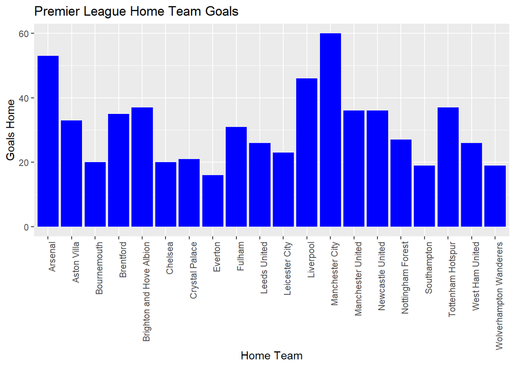

```r
#plot for home team goals vs away team goals
#install.packages("ggplot2")
library(ggplot2)
plot1 <- ggplot(data = dataset, aes(x = `Home.Team`, y = `Goals.Home`)) +
  geom_bar(stat = "identity", fill = "blue") +
  labs(title = "Premier League Home Team Goals",
       x = "Home Team",
       y = "Goals Home") +
  theme(axis.text.x = element_text(angle = 90, hjust = 1))

plot2 <- ggplot(data = dataset, aes(x = `Away.Team`, y = `Away.Goals`)) +
  geom_bar(stat = "identity", fill = "red") +
  labs(title = "Premier League Away Team Goals",
       x = "Away Team",
       y = "Goals Away") +
  theme(axis.text.x = element_text(angle = 90, hjust = 1))
print(plot1)
```

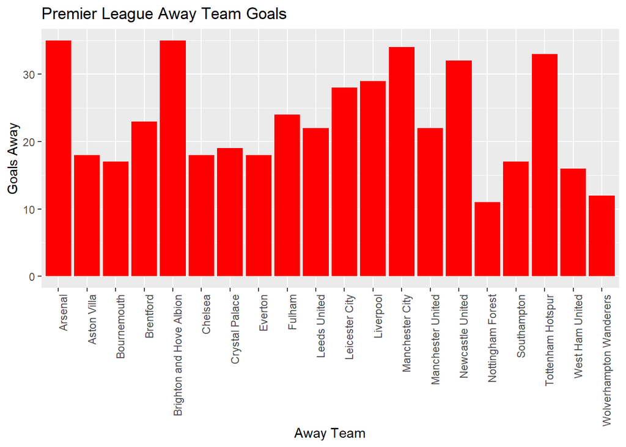

```r
print(plot2)
```

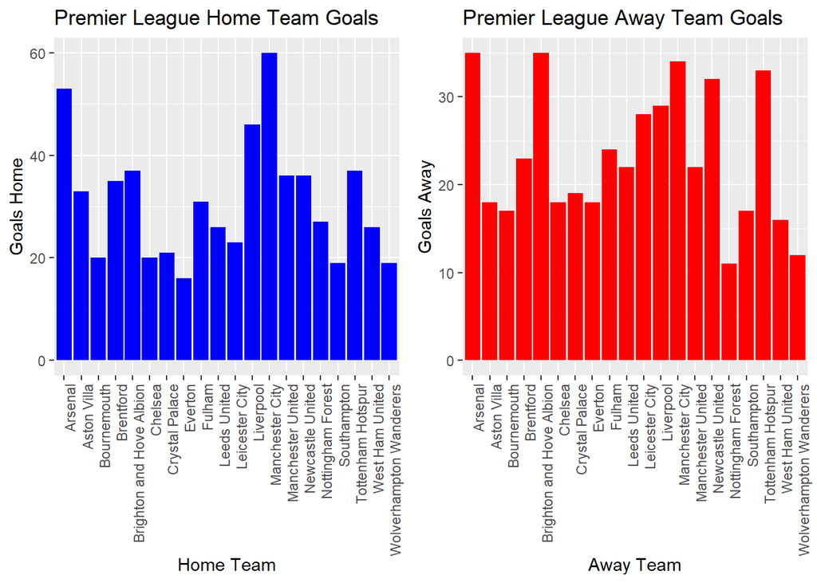

```r
# Combine both plots
combined_plot <- grid.arrange(plot1, plot2, ncol = 2)
```

```r
# Display the combined plot
print(combined_plot)
```

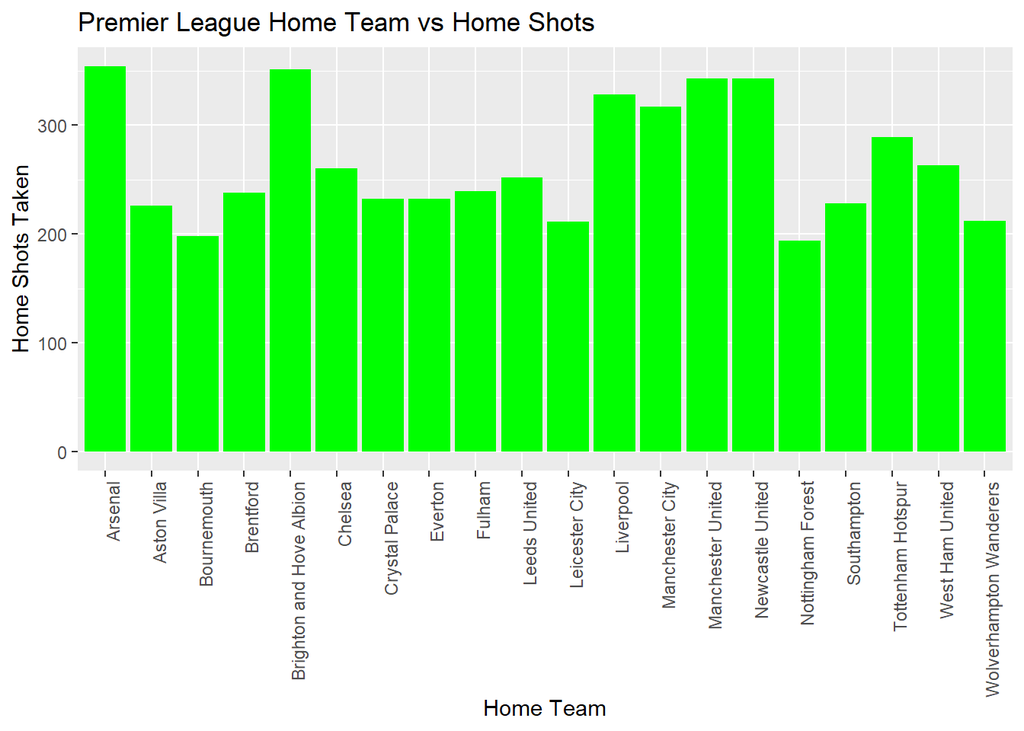

```r
#Home team vs home shots and away team vs away shots
plot1 <- ggplot(data = dataset, aes(x = `Home.Team`, y = `home_shots`)) +
  geom_bar(stat = "identity", fill = "green") +
  labs(title = "Premier League Home Team vs Home Shots",
       x = "Home Team",
       y = "Home Shots Taken") +
  theme(axis.text.x = element_text(angle = 90, hjust = 1))

plot2 <- ggplot(data = dataset, aes(x = `Away.Team`, y = `away_shots`)) +
  geom_bar(stat = "identity", fill = "lightblue") +
  labs(title = "Premier League Away Team vs Away Shots",
       x = "Away Team",
       y = "Away shots Taken") +
  theme(axis.text.x = element_text(angle = 90, hjust = 1))
print(plot1)
```

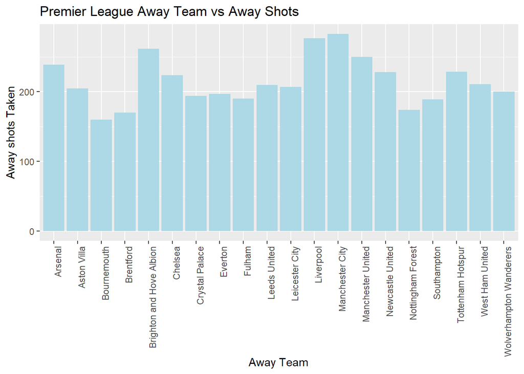

```r
print(plot2)
```

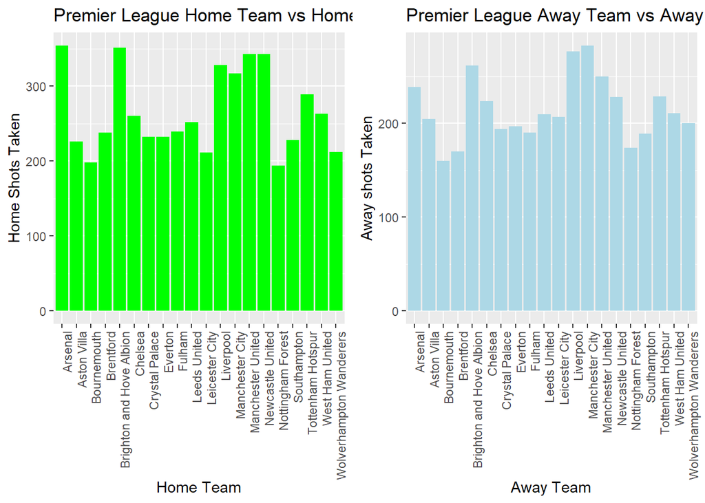

```r
# Combine both plots
combined_plot <- grid.arrange(plot1, plot2, ncol = 2)
```

```r
# Display the combined plot
print(combined_plot)
```

- The above output has two graphs combined. one plot is for home team vs home shots taken and another plot shows away team vs away shots taken. we can infer from the graph that Arsenel holds the highest no of shots taken in home games and man city holds the highest no of shots taken in away games

```r
# Load the dplyr package
library(dplyr)


# Calculate points and goal difference
table_data <- dataset %>%
  mutate(Winner = ifelse(Goals.Home > Away.Goals, Home.Team,
                         ifelse(Away.Goals > Goals.Home, Away.Team, "Draw"))) %>%
  group_by(Team = ifelse(Winner == "Draw", Home.Team, Winner)) %>%
  summarise(
    Matches_Played = n(),
    Wins = sum(Winner == Team),
    Draws = sum(Winner == "Draw"),
    Losses = sum(Winner != Team & Winner != "Draw"),
    Goals_For = sum(ifelse(Home.Team == Team, Goals.Home, Away.Goals)),
    Goals_Against = sum(ifelse(Home.Team == Team, Away.Goals, Goals.Home)),
    Goal_Difference = Goals_For - Goals_Against,
    Points = 3 * Wins + Draws
  ) %>%
  arrange(desc(Points), Goal_Difference)  # Omit asc() for Goal_Difference

# Display the table
print(table_data)
```

```
## # A tibble: 20 × 9
##    Team                Matches_Played  Wins Draws Losses Goals_For Goals_Against
##    <chr>                        <int> <int> <int>  <int>     <int>         <int>
##  1 Manchester City                 29    28     1      0        86            20
##  2 Arsenal                         29    26     3      0        80            23
##  3 Manchester United               26    23     3      0        47            10
##  4 Newcastle United                25    19     6      0        62            17
##  5 Liverpool                       24    19     5      0        63            19
##  6 Brighton and Hove …             22    18     4      0        54            14
##  7 Aston Villa                     20    18     2      0        39             9
##  8 Tottenham Hotspur               19    18     1      0        47            14
##  9 Brentford                       22    15     7      0        45            15
## 10 Fulham                          20    15     5      0        44            21
## 11 Chelsea                         18    11     7      0        30            13
## 12 Crystal Palace                  18    11     7      0        31            13
## 13 Bournemouth                     15    11     4      0        25             9
## 14 West Ham United                 15    11     4      0        29             7
## 15 Wolverhampton Wand…             14    11     3      0        19             4
## 16 Nottingham Forest               15     9     6      0        23            12
## 17 Leicester City                  13     9     4      0        32            11
## 18 Leeds United                    14     7     7      0        26            16
## 19 Everton                         11     8     3      0        17             4
## 20 Southampton                     11     6     5      0        20            14
## # ℹ 2 more variables: Goal_Difference <int>, Points <dbl>
```

```r
# Determine the winner
winner <- table_data$Team[1]
cat("The winner is:", winner, "\n")
```

```
## The winner is: Manchester City
```

## *The above output calculates the points table and finds which team wins the title.

**Result : we have done data analysis and data visualiztion on 2022-23 premier league dataset . we have used various analysis and visualization to analyse data . As a result , we can infer Manchester city has played very well in this season and manchester is blue**